# Getting started with EMIT imaging spectroscopy data

Anna Schweiger

### Load packages

```r
library(RNetCDF)
library(spectrolab)
library(raster)
library(rgdal)
```

### Downloading EMIT data

Great tutorials for downloading **EMIT** data can be found on NASA’s EMIT-Data-Resources [Github](https://github.com/nasa/EMIT-Data-Resources). The entire repository is worth checking out, but scripts are in python.

For **bulk download** see the [NASA Earthdata Wiki] (https://wiki.earthdata.nasa.gov/display/EDSC/How+To%3A+Use+the+Download+Access+Script.)

The one tile we will use in this tutorial can accessed here, or follow the link in the **test_data**:  
[**L2A reflectance**](https://data.lpdaac.earthdatacloud.nasa.gov/lp-prod-protected/EMITL2ARFL.001/EMIT_L2A_RFL_001_20230812T223333_2322415_006/EMIT_L2A_RFL_001_20230812T223333_2322415_006.nc)  
[**Uncertainty**](https://data.lpdaac.earthdatacloud.nasa.gov/lp-prod-protected/EMITL2ARFL.001/EMIT_L2A_RFL_001_20230812T223333_2322415_006/EMIT_L2A_RFLUNCERT_001_20230812T223333_2322415_006.nc)  
[**Μask**](https://data.lpdaac.earthdatacloud.nasa.gov/lp-prod-protected/EMITL2ARFL.001/EMIT_L2A_RFL_001_20230812T223333_2322415_006/EMIT_L2A_MASK_001_20230812T223333_2322415_006.nc)

### Open the .nc file and inspect data structure

This does not load the data, which is a good thing. This is a large file! Set pp to the folder you want to work in and that contains the example data

```r
pathi <- "./test_data/EMIT_L2A_RFL_001_20230812T223333_2322415_006.nc"
dat <- ncdf4::nc_open(pathi)
```

Take some time and explore the file:

```r
str(dat)
names(dat)
names(dat$var)
```

This is were our variables live! Let’s load the data, note that the .nc file needs to be already open. This takes a moment.

```r
refl <- ncdf4::ncvar_get(dat, "reflectance")
```

### Plot spectra

Let’s look at the data:

```r
dim(refl) ### this is a data cube
```

```
## [1]  285 1242 1280
```

```r
str(refl)
```

```
##  num [1:285, 1:1242, 1:1280] 0.0252 0.0262 0.0228 0.038 0.0382 ...
```

Let’s see if we can look at our spectra with `spectrolab`. We start with loading one spectrum into spectrolab. Note when referencing that `refl` is a 3-dimensional array consisting of 285 band-wise reflectance values in dimension 1, 1242 pixel locations in x, and 1280 pixel locations in y.

```r
spec1 <- refl[,1,1] ## one pixel
str(spec1) ## we need a matrix to make a spectra object
```

```
##  num [1:285] 0.0252 0.0262 0.0228 0.038 0.0382 ...
```

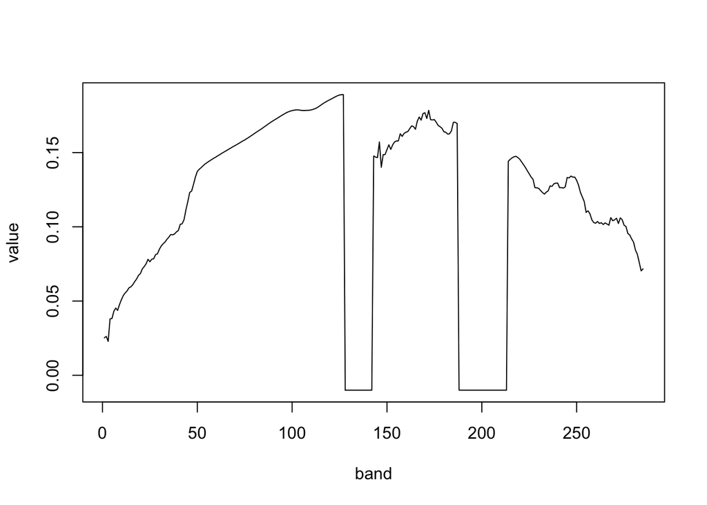

```r
spec_mat <- matrix(data = spec1, nrow = 1, dimnames = list(NULL, c(1:length(spec1))))

spec1_s <- as_spectra(spec_mat)
plot(spec1_s)
```

Not bad. We can see the water absorption band cut out. But we need some more information to make sense of this. Let’s go back to our `dat` object and extract the wavelength information.

```r
names(dat$var)
```

```
## [1] "reflectance"
## [2] "sensor_band_parameters/wavelengths"
## [3] "sensor_band_parameters/fwhm"
## [4] "sensor_band_parameters/good_wavelengths"
## [5] "location/lon"
## [6] "location/lat"
## [7] "location/elev"
## [8] "location/glt_x"
## [9] "location/glt_y"
```

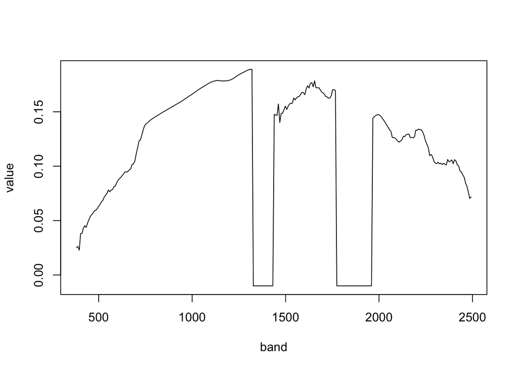

```r
wvl <- ncdf4::ncvar_get(dat, dat$var$`sensor_band_parameters/wavelengths`)
wvl_good <- ncdf4::ncvar_get(dat, dat$var$`sensor_band_parameters/good_wavelengths`)

bands(spec1_s) <- as.numeric(wvl)
plot(spec1_s)
```

Better! And we even know which wavelengths have been cut out due to water absorption. Can you figure out which?

## Create raster stack

Imaging spectroscopy collects geospatial data, images across certain extents of the globe. In the next couple lines we will re-construct these spatial data from the .nc file using R’s well known `raster` package.

Let’s start with exploring the data structure and loading some useful information into R.

```r
spec <- refl[,,]
str(spec)
```

```
##  num [1:285, 1:1242, 1:1280] 0.0252 0.0262 0.0228 0.038 0.0382 ...
```

```r
lon <- ncdf4::ncvar_get(dat,dat$var$`location/lon`) ## geographic coordinates per pixel
lat <- ncdf4::ncvar_get(dat,dat$var$`location/lat`)

reso <- 60 ## spatial resolution in meters
orig_crs <- "EPSG:4326" ## coordinate reference system
```

Let’s start with rasterizing one band across the entire extent.

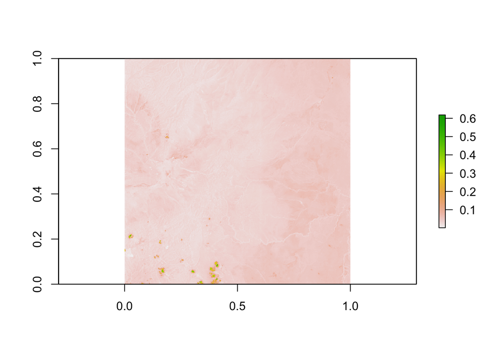

```r
spec_b1 <- spec[1,,]
outr <- raster(t(spec_b1)) ## the matrix needs to be transposed. Rasters are filled line by line starting at the lower left corner.

plot(outr)
```